# STA257

Last edited: 2016-12-04 09:45

## some sums of r.v.s

If \(X_1,\ldots,X_n\) are i.i.d. Bernoulli\((p)\), then \(\sum X_i \sim \text{Binomial}(n,p)\)…

If \(X_1,\ldots,X_n\) are i.i.d. Geometric\((p)\), then \(\sum X_i \sim \text{NegBin}(n,p)\)…

This is fundamentally a "lookup table" technique.

Others (exercises):

- sum of \(n\) independent Exp\((\lambda)\) is Gamma\((n,\lambda)\)
- sum of \(n\) independent Poisson\((\lambda)\) is Poisson\((n\lambda)\)
- sum of \(X_i\sim\text{Binomial}(n_i, p)\) is Binomial\(\left(\sum n_i, p\right)\)
- distribution of sum of \(X_i\sim\text{Binomial}(n_i, p_i)\) (different p_i!) cannot be determined using mgf technique.

## the normal distributions

First, suppose \(X\) has mgf \({m_{\tiny{X}}}(t)\) and \(Y = a + bX\). What is \({m_{\tiny{Y}}}(t)\)?

So what is the mfg of a general \(N(\mu, \sigma^2)?\)

Finally, if \(X_1,\ldots,X_n\) are independent with \(X_i\sim N(\mu_i, \sigma^2_i)?\), what distribution is \(X=\sum X_i?\)

## sequences of random variables, convergence

## (optional background) sequences of functions

Depending on your background, you might have heard of:

- pointwise convergence \(f_n(x) \to f(x)\) (converges for every \(x\))
- uniform convergence (convergence happens all at the same rate

Uniform convergence is stronger and has benefits - you can pass limits, derivatives, integrals, etc. through uniform convergence with no problem.

In this course we have sometimes magically passed these things along with the \({E\!\left(\right)}\) operator through *power series*, because power series converge *uniformly* inside their radius of convergence.

But don't worry if you've never heard of this or forgot it all.

## sequences of random variables

Very common in probability and statistics. We have seen some already:

As a model for a variable in a dataset we have considered the "i.i.d." sequence \(X_1,X_2,\ldots,X_n.\)

I have introduced the notion of "Sample Average" \(\overline X_n = \frac{1}{n}\sum\limits_{i=1}^n X_i\).

When we derived Poisson from Binomial, we (implicitly) considered a sequence \(X_n \sim \text{Binomial}\left(n, \frac{\lambda}{n}\right)\) and wondered about \(n\to\infty.\)

We're going to wonder again about \(n\to\infty\)

Again, with random variables we care most about probabilities and not their actual values.

## Case 1: getting closer to a constant, probably

Consider \(X_1,X_2,\ldots,X_n\) i.i.d. with \({E\!\left(X_i\right)}=\mu\) and \({\text{Var}\!\left(X_i\right)}=\sigma^2,\) and consider \(\overline X_n = \frac{1}{n}\sum\limits_{i=1}^n X_i.\)

From last week: \[{E\!\left(\overline X_n\right)} = \mu \qquad \text{and} \qquad {\text{Var}\!\left(\overline X_n\right)} = \frac{\sigma^2}{n}\] What happens when \(n\) gets bigger?

## simulation example 1 - Bernoulli(0.5)

My computer can pretend to observe Bernoulli random variables. Here are \(n=30\) Binomial(1,0.5) simulations:

```r
rbinom(n=30, size=1, prob=0.5)
```

```
##  [1] 1 1 0 0 0 0 1 1 0 1 1 1 1 1 1 1 1 0 1 0 1 1 0 1 0 0 0 1 1 1
```

I am going to let \(n\) get larger and plot \(n\) versus cumulative values of \(\overline{X}_n.\)

## simulation example 1 - Bernoulli(0.5)

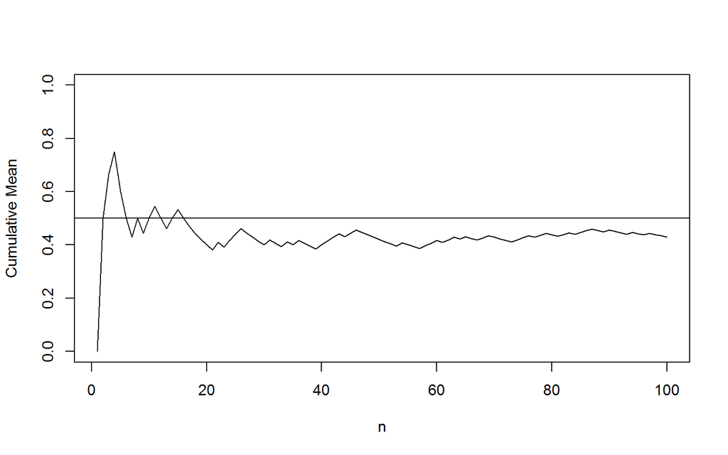

## simulation example 1 - Bernoulli(0.5)

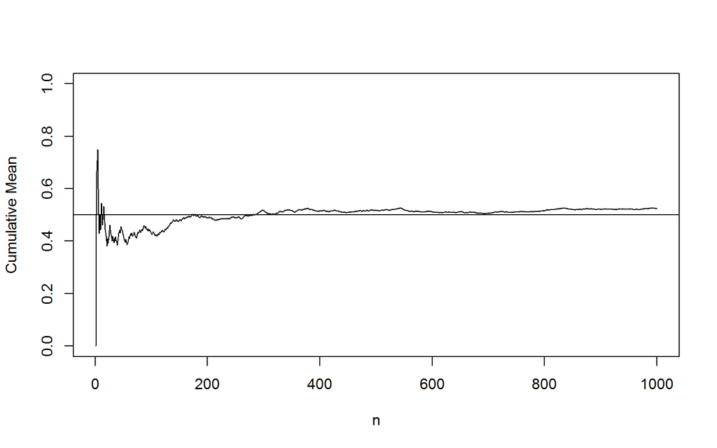

## simulation example 1 - Bernoulli(0.5)

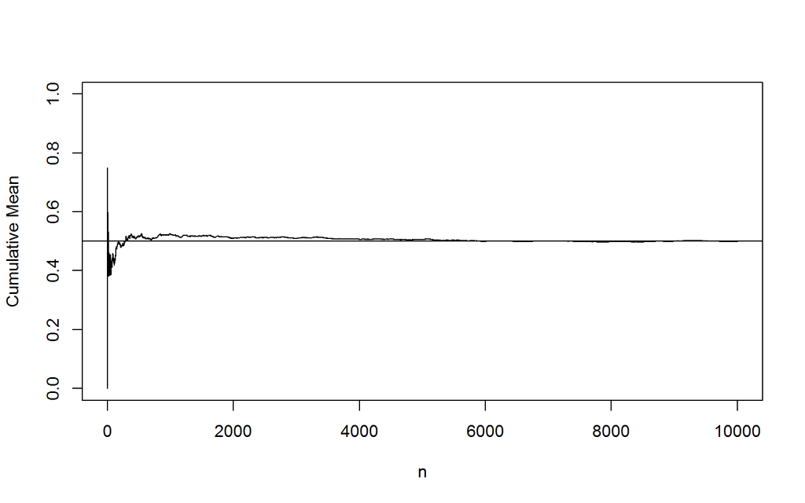

## simulation example 2 - Exponential(0.25)

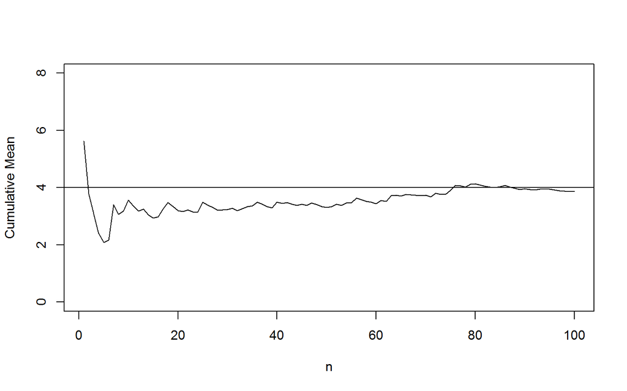

## simulation example 2 - Exponential(0.25)

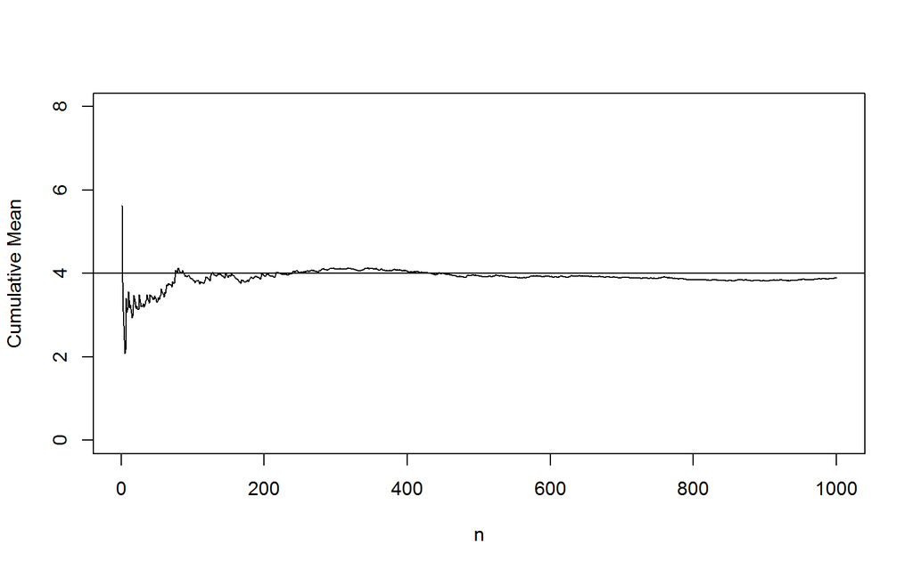

## simulation example 2 - Exponential(0.25)

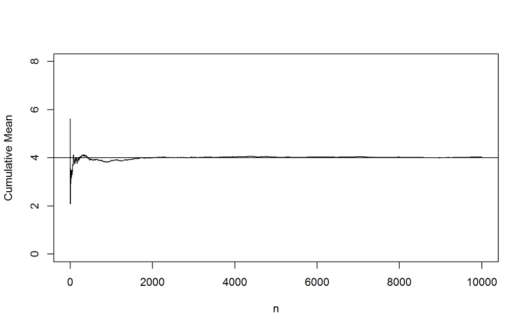

## simulation example 3 - The *Neil* distribution

Positive random variable \(X\) with density \(\frac{8}{\pi}\frac{x}{x^4 + 4}\)

\(E(X) = 2\) (hard!!) and \({\text{Var}\!\left(X\right)}\) does not exist.

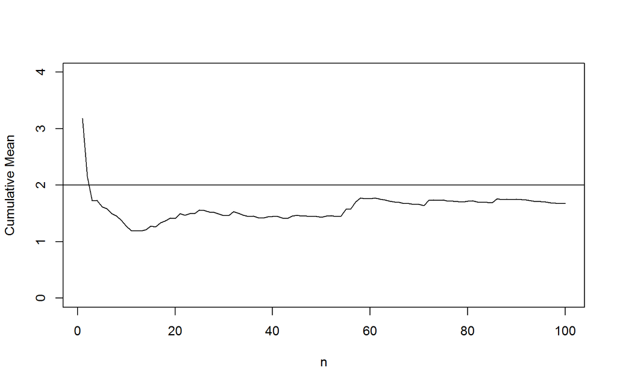

## simulation example 3 - The *Neil* distribution

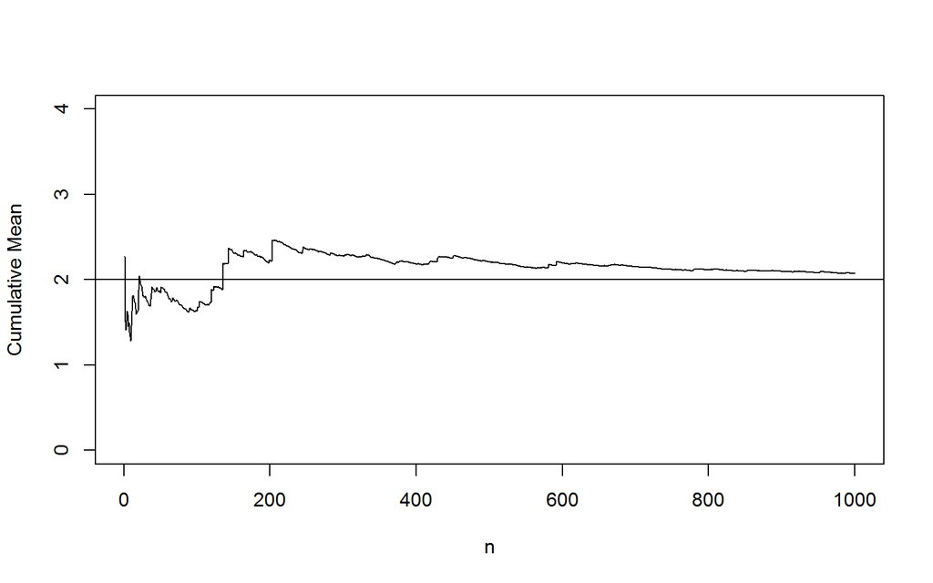

## simulation example 3 - The *Neil* distribution

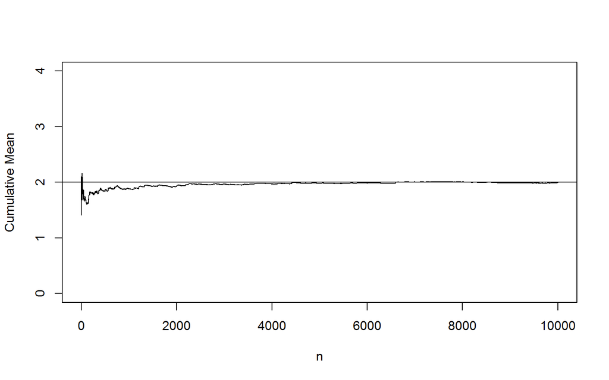

## simulation example 3 - the *Neil* distribution

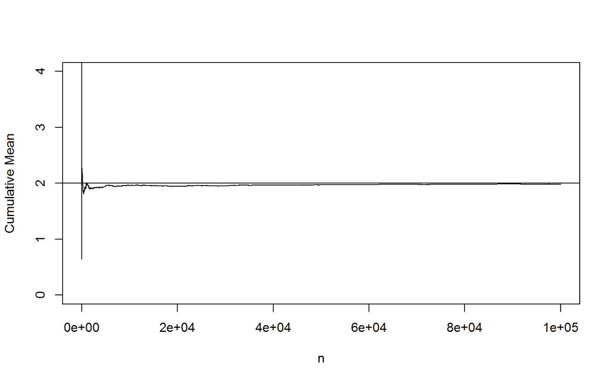

## simulation example 4 - the Cauchy distribution

Density \(\frac{1}{\pi}\frac{1}{1+x^2}.\) No expected value

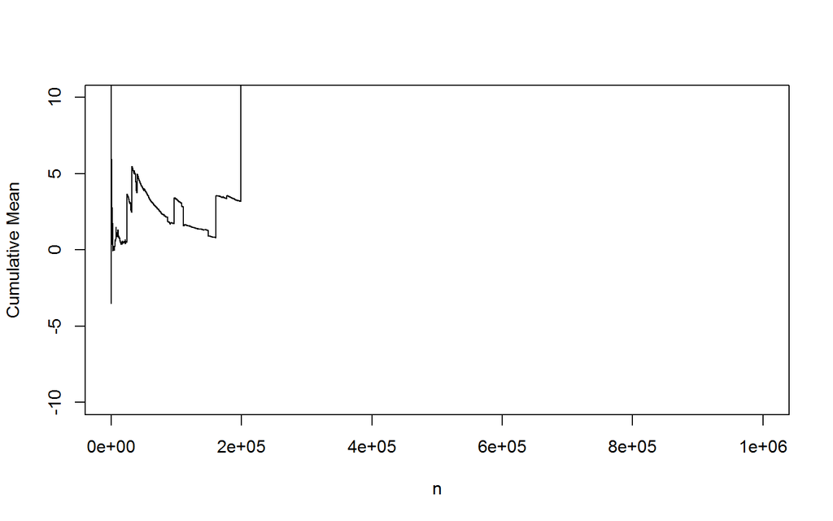

## the (weak) Law of Large Numbers

Examples 1 and 2 had random variables with mean \(\mu\) and variance \(\sigma^2.\) The convergence of the \(\overline{X}_n\) to \(\mu\) is explained by…

Theorem: If \(X_1, X_2, X_3,\ldots\) are independent with the same mean \(\mu\) and variance \(\sigma^2,\) then for all \(\epsilon > 0\): \[\lim_{n\to\infty} {P{\left(\left|\overline{X}_n - \mu\right| > \varepsilon\right)}} = 0.\]

Proof:…

This does *not* explain example 3 (no variance), and doesn't really explain 4 either.

Good for theory and philosophy. Not so good in practice (rate of convergence?)

## convergence in probability

The WLLN is an example of *convergence in probability*: \[\lim_{n\to\infty} {P{\left(\left|X_n - X\right| > \varepsilon\right)}} = 0,\] and in the WLLN \(X=\mu\) is a constant random variable.

Common notation: \(X_n \overset{P}\longrightarrow X\)

Convergence in probability has to do with *values* of random variables.

The *distribution* of \(X\) (what we care about) only deals with things like \(P(a < X < b),\) which is less stringent than convergence in probability.

## convergence in distribution

Roughly speaking, the distribution of \(X_n\) converges to the distribution of \(X\) if their cdfs converge: \({F_{\tiny{X_n}}} \to {F_{\tiny{X}}}\)

Formal definition: \(X_n\) *converges in distribution* to \(X\) if \[\lim_{n\to\infty} {F_{\tiny{X_n}}}(x) = {F_{\tiny{X}}}(x)\] at every point where \({F_{\tiny{X}}}(x)\) is continuous.

Common notations: \[X_n \Longrightarrow X\\ X_n \overset{D}\longrightarrow X\]

Definition not so easy to use.

## verifying convergence in distribution

Stated without proof; all imply \(X_n {\overset{D}\longrightarrow}X\).

Theorem: \(X_n\) with pmf \({p_{\tiny{X_n}}}(x)\) that converge to a pmf \({p_{\tiny{X}}}(x)\)…

Example: \(X_n \sim \text{Binomial}\left(n,\frac{\lambda}{n}\right)\) and \(X\sim\text{Poisson}(\lambda)\)

Theorem: \(X_n\) with density \({f_{\tiny{X_n}}}(x)\) that converge to a density \({f_{\tiny{X}}}(x)\)…

Future example for STA261 students: \(X_n \sim t_n\) and \(X\sim N(0,1)\)

**THEOREM**: \(X_n\) with m.g.f. \({m_{\tiny{X_n}}}(t)\) that converge to an m.g.f. \({m_{\tiny{X}}}(t)\) in a neighborhood of 0 implies \(X_n {\overset{D}\longrightarrow}X\).

Example: \(X_n \sim \text{Binomial}\left(n,\frac{\lambda}{n}\right)\)…

## the fundamental theorem of statistics

## the distribution of \(\overline{X}_n\)

Let's consider again \(X_1,X_2,\ldots\) now i.i.d. with m.g.f. \(m(t)\). The common mean and variance are \(\mu\) and \(\sigma^2\).

\({E\!\left(\overline X_n\right)}=\mu\) and \({\text{Var}\!\left(\overline X_n\right)} = \frac{\sigma^2}{n}\)

Consider: \[Y_n = \frac{\overline X_n - \mu}{\sigma/\sqrt{n}}\]

Then \({E\!\left(Y_n\right)}=0\) and \({\text{Var}\!\left(Y_n\right)}=1\).

What could be said about the *distribution* of \(Y_n\)?

## histograms (for simulating \(Y_n\))

A *histogram* takes a sequence of numbers (the "data"), splits the range into "bins", and produces a bar graph of the count inside each bin.

A histogram is a "density estimator". Here's a histogram of \(k=100\) randomly samples from an \(\text{Exp}(1)\) distribution, with the density in red:

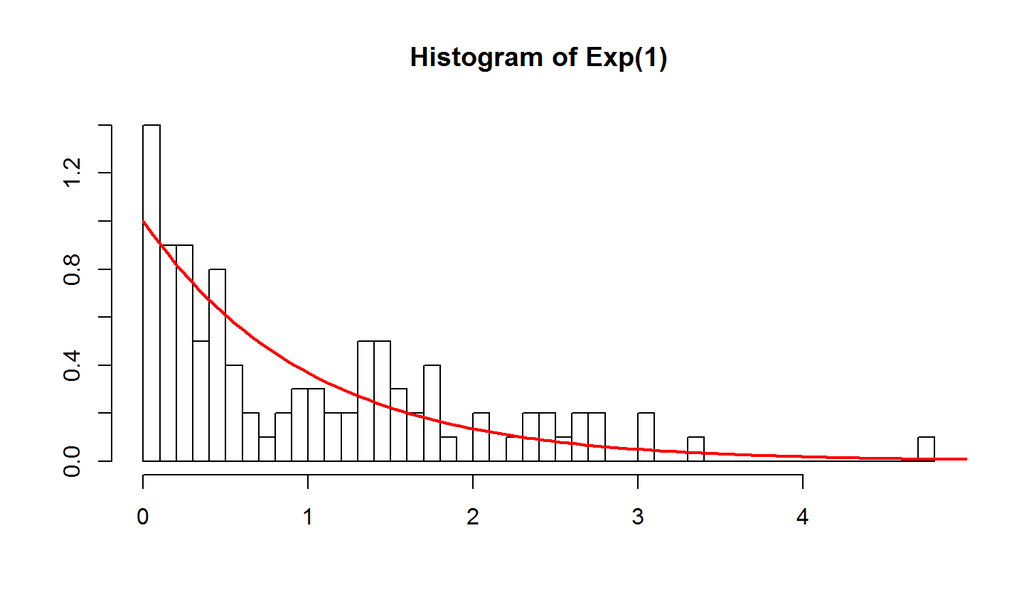

## more simulation = smoother histogram

\(k=10^{4}\)

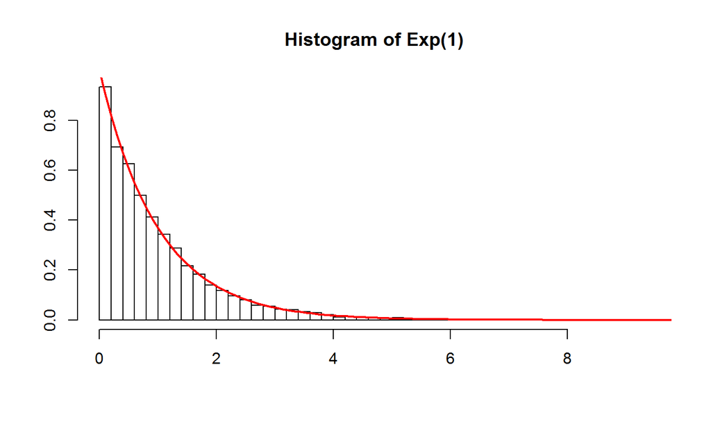

## simulating \(Y_n\)

Fix \(n\) and a distribtion for \(X_i\).

1. Simulate a sample of size \(n\) from the distribution.
2. Calculate \(Y_n^{(1)}\) from this sample.
3. Repeat \(k\) times to obtain \(Y_n^{(1)},\ldots,Y_n^{(k)}\)
4. Make a histogram of the \(Y_n^{(j)}\)

Important: \(n\) is fixed and fundamental to the simulation. A larger \(k\) makes a nicer histogram and is more of a choice to make.

## example 1 with \(n=10\) and \(X_i \sim \text{Geometric}(1/3)\)

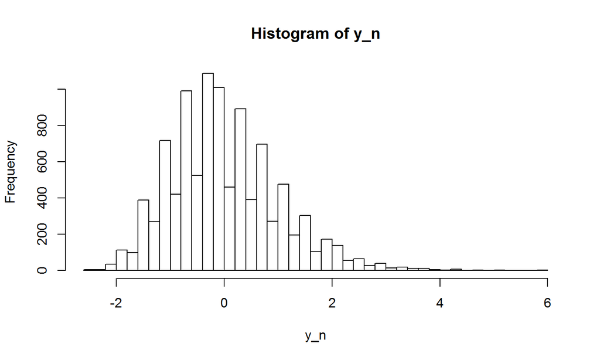

## example 1 with \(n=50\) and \(X_i \sim \text{Geometric}(1/3)\)

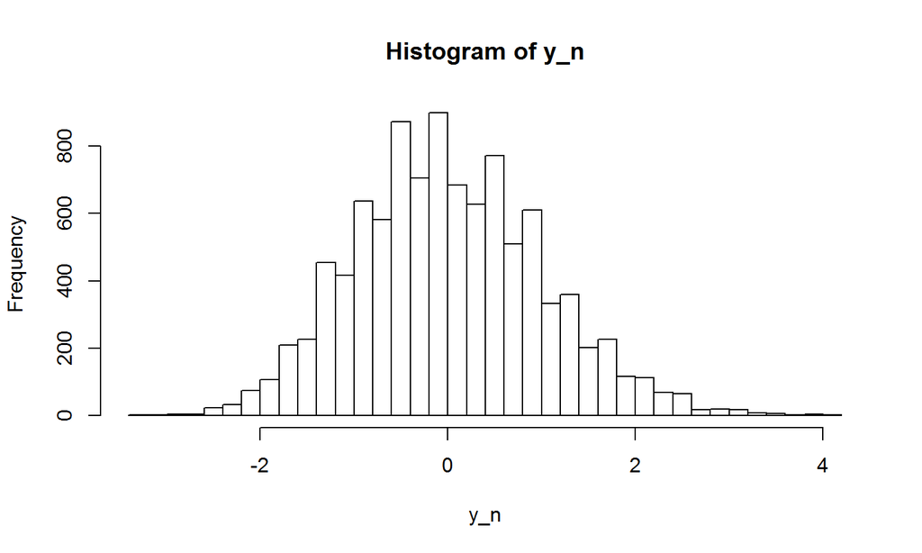

## example 1 with \(n=500\) and \(X_i \sim \text{Geometric}(1/3)\)

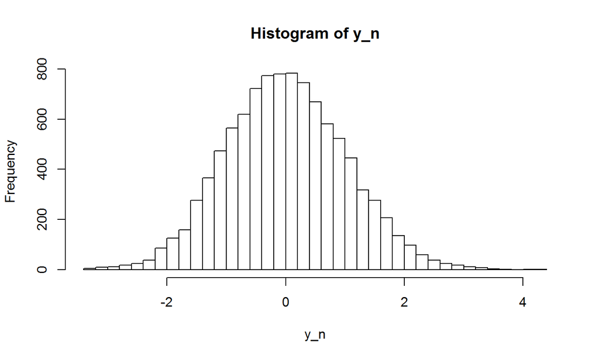

## example 2 with \(n=10\) and \(X_i \sim \text{Exp}(0.25)\)

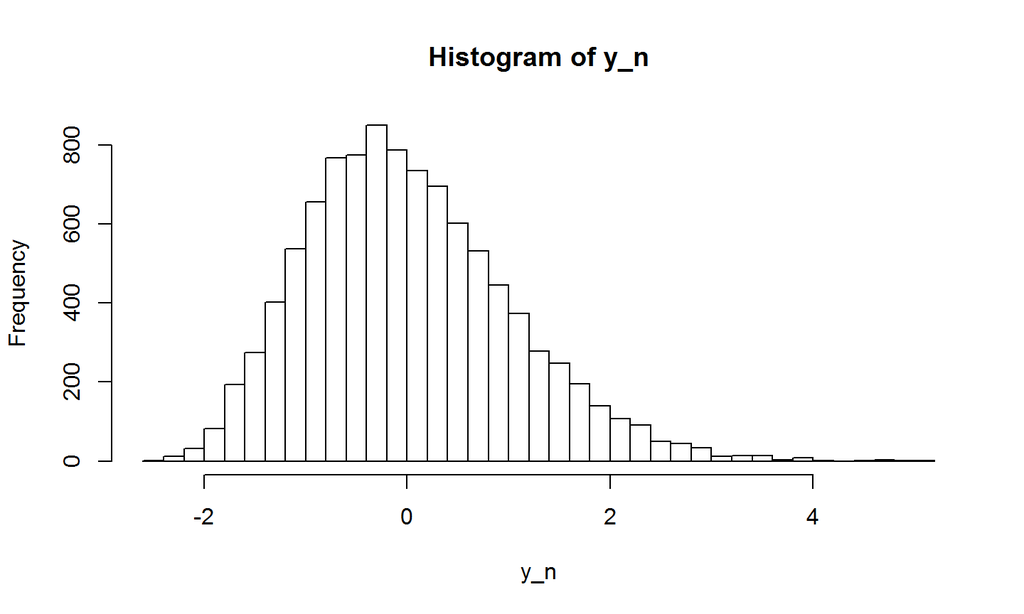

## example 2 with \(n=50\) and \(X_i \sim \text{Exp}(0.25)\)

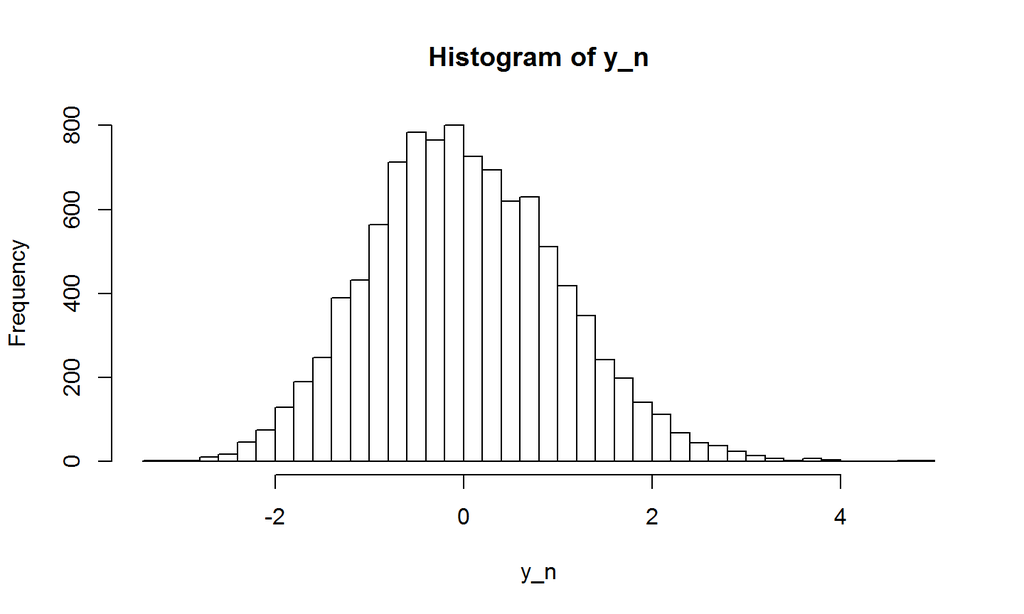

## example 2 with \(n=500\) and \(X_i \sim \text{Exp}(0.25)\)

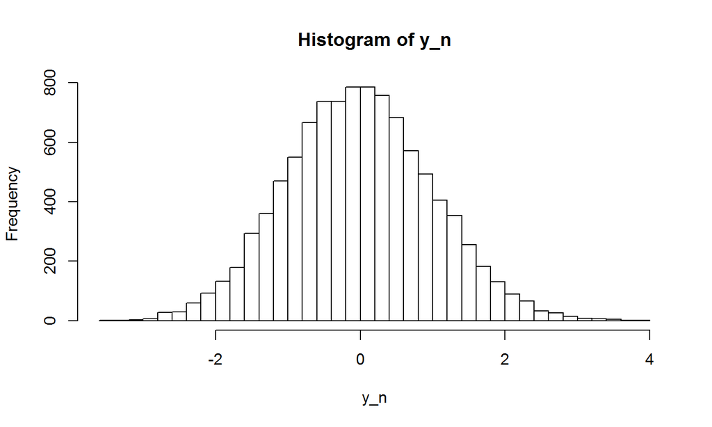

## The Central Limit Theorem

Theorem: \(X_1,X_2,\ldots\) are i.i.d. with m.g.f. \(m(t)\), mean \(\mu\), and variance \(\sigma^2\). Then: \[\frac{\overline X_n - \mu}{\sigma/\sqrt{n}} {\overset{D}\longrightarrow}Z\] where \(Z\sim N(0,1).\)

Proof:…

This is a *limit theorem*. What is crucial is that the convergence can be *fast*.

## normal approximations

For \(X_1,X_2,\ldots,X_n\) with mean \(\mu\) and variance \(\sigma^2\) and \(n\) large enough*

\[\sum\limits_{i=1}^n X_i \sim^\text{approx} N(n\mu, n\sigma^2)\\ \overline{X} \sim^\text{approx} N\left(\mu,\frac{\sigma^2}{n}\right)\\ \frac{\overline{X} - \mu}{\sigma/\sqrt{n}} \sim^\text{approx} N(0,1)\]

* depends on the underlying distribution. The more "skewed" or "heavy-tailed", the larger the \(n\) required.

## example - Uniform(0,1)

\(X_1,X_2,\ldots,X_n\) are Uniform(0,1) and \(n=20.\) What's the chance that \(\sum X_i > 11\)